# Ejercicio 11

Hairo Ulises Miranda Belmonte

20 de abril de 2019

## Ejercicio 11

**a) Resuelve $tanh(x)=0$ por el método der Newton y estudie los detalles intermedios del algoritmo. Cominece con $x_0=1.08$. Grafica la tangente en cada iteración del método de Newton. Luego repita los cálculos y el trazado cuando $x_0=1.09$. Explica lo que observa**

Se progtama la función del método de Newton que se encuentra a continuación.

```r
# metodo de newthon
newton <- function(x0){
# funcion
f <- function(x) {
  tanh(x)
}
# derivada de la función
f1 <- function(x) {
  1 - tanh(x)^2
}
# gráfico inicial
plot(f,c(-10,20))
abline(0,0)
# valor inicial
x <- x0
t <- 0
# algoritmo
while(x!=0){
  if(x>10^10){
    print("Valor overflow")
    break
  } else if(x< (-10^(10))){
    print("Valor underflow")
    break
  } else{
  x <- x-(f(x)/f1(x))
  x
  f(x)
  abline(f(x),f1(x), col="red")
  t <- t+1
  print(paste("iteración:", t))
  print(paste("valor de x:",x))
  Sys.sleep(1)
  } # end if
}# end while
} # end newton
```

Se da un valor inicial de $x_0=1.08$.

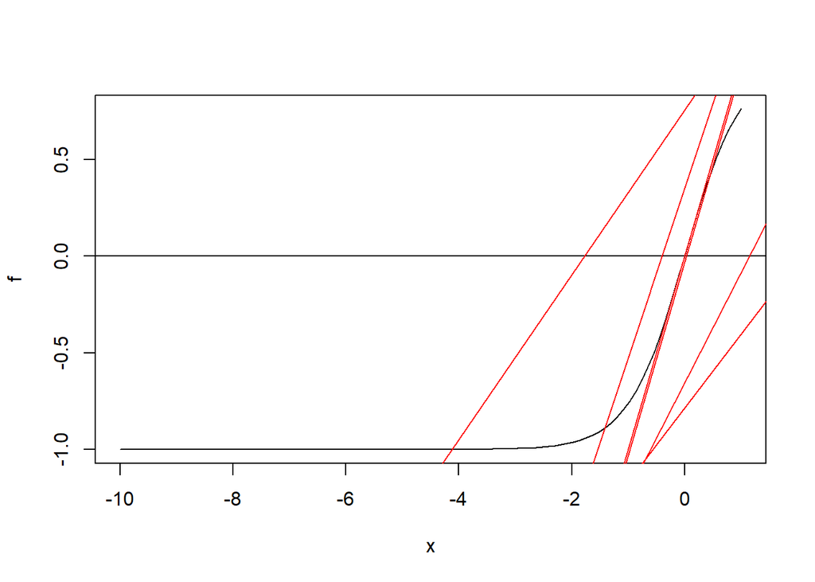

```
## [1] "iteración: 1"
## [1] "valor de x: -1.05895313435635"
## [1] "iteración: 2"
## [1] "valor de x: 0.989404207298238"
## [1] "iteración: 3"
## [1] "valor de x: -0.784566773085778"
## [1] "iteración: 4"
## [1] "valor de x: 0.363998161110007"
## [1] "iteración: 5"
## [1] "valor de x: -0.0330146961371957"
## [1] "iteración: 6"
## [1] "valor de x: 2.39952526680035e-05"
## [1] "iteración: 7"
## [1] "valor de x: -9.2105312363578e-15"
## [1] "iteración: 8"
## [1] "valor de x: 0"
```

```r
newton(1.08)
```

Se observa que con el valor inicial de $1.08$, el mpetodo de newton encuentra la raíz en la iteración $8$

Ahora se asigna el valor inicial de $x_0=1.09$.

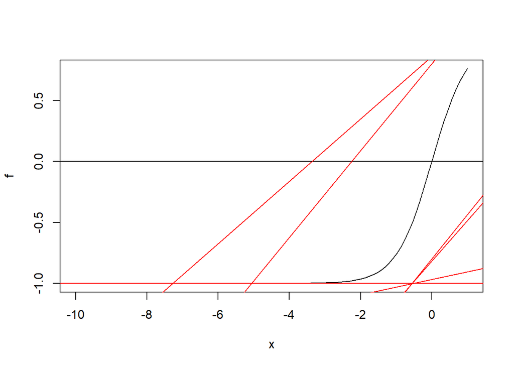

```
## [1] "iteración: 1"
## [1] "valor de x: -1.09331618202011"
## [1] "iteración: 2"
## [1] "valor de x: 1.10490354324441"
## [1] "iteración: 3"
## [1] "valor de x: -1.14615550788119"
## [1] "iteración: 4"
## [1] "valor de x: 1.3030326182333"
## [1] "iteración: 5"
## [1] "valor de x: -2.06492300237764"
## [1] "iteración: 6"
## [1] "valor de x: 13.4731428005785"
## [1] "iteración: 7"
## [1] "valor de x: -126055913647.137"
## [1] "Valor underflow"
```

```r
newton(1.09)
```

**b)Resuelve el problema $tanh(x)=0$ mediante método Secante con el valor inicial $x_0=1.08$ y $x_1=1.09$, Explica lo que observas**

Se programa la función del algoritmo del método de Secante.

```r
secante <- function(f, x0, x1, tol = 1e-9, n = 500) {
  # función
  f <- function(x) {
  tanh(x)
  }
  t <- 0
  # Gráfico inicial
  curve(expr = f, col='blue', lwd=2, lty=2, xlim=c(-1,5))
  abline(h=0)
  abline(v=0)
  a <- f(x0)
  b <- f(x1)
  # punto de la iteración
  points(x0, a, cex=1, pch=22, bg='blue', col='blue')
  points(x1, b, cex=1, pch=22, bg='red', col='red')
  segments(x0, a, x1, b, col='red', lwd = 2)
  print(paste("iteración:", t))
  print(paste("valor de x0:",x0))
  print(paste("valor de x1:",x1))
  # algoritmo secante
  for (i in 1:n) {
      x2 <- x1 - f(x1) / ((f(x1) - f(x0)) / (x1 - x0)) # Calculate the new x value
      a <- f(x1)
      b <- f(x2)
      print(paste("iteración:", t+1))
      print(paste("valor de x t:",x1))
      print(paste("valor de x t+1:",x2))
      Sys.sleep(1)
      curve(expr = f, col='blue', lwd=2, lty=2, xlim=c(-1,5))
      abline(h=0)
      abline(v=0)
      points(x1, a, cex=1, pch=22, bg='blue', col='blue')
      points(x2, b, cex=1, pch=22, bg='red', col='red')
      segments(x1, a, x2, b, col='red', lwd = 2)
     if (abs(x2 - x1) < tol) {
        return(x2)
      } # end if
      x0 <- x1
      x1 <- x2
      t <- t+1
    } # end for
  } # end secante
```

Se utiliza la función Secante con lo valores iniciales que se indicaron.

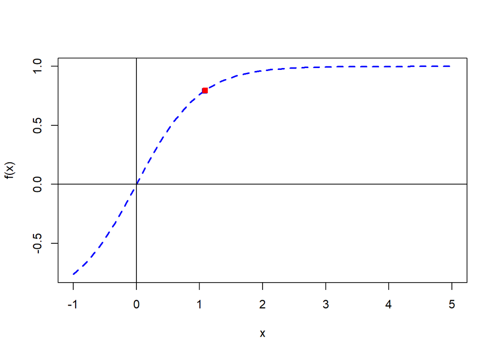

```
## [1] "iteración: 0"
## [1] "valor de x0: 1.08"
## [1] "valor de x1: 1.09"
## [1] "iteración: 1"
## [1] "valor de x t: 1.09"
## [1] "valor de x t+1: -1.07599058926764"
```

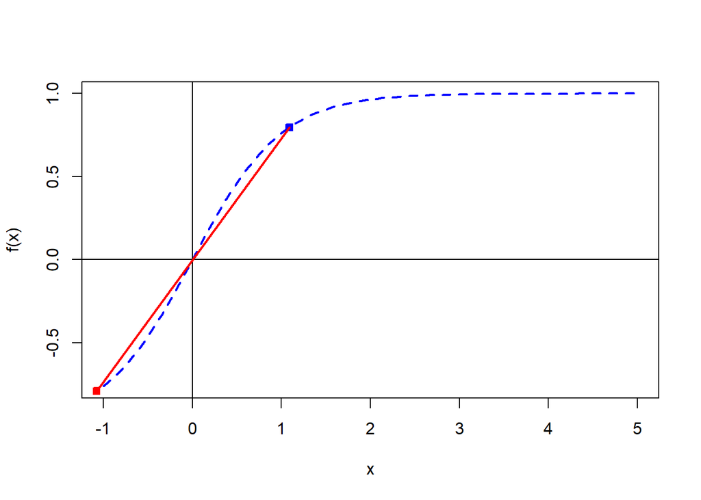

```
## [1] "iteración: 2"
## [1] "valor de x t: -1.07599058926764"
## [1] "valor de x t+1: 0.00347971457680663"
```

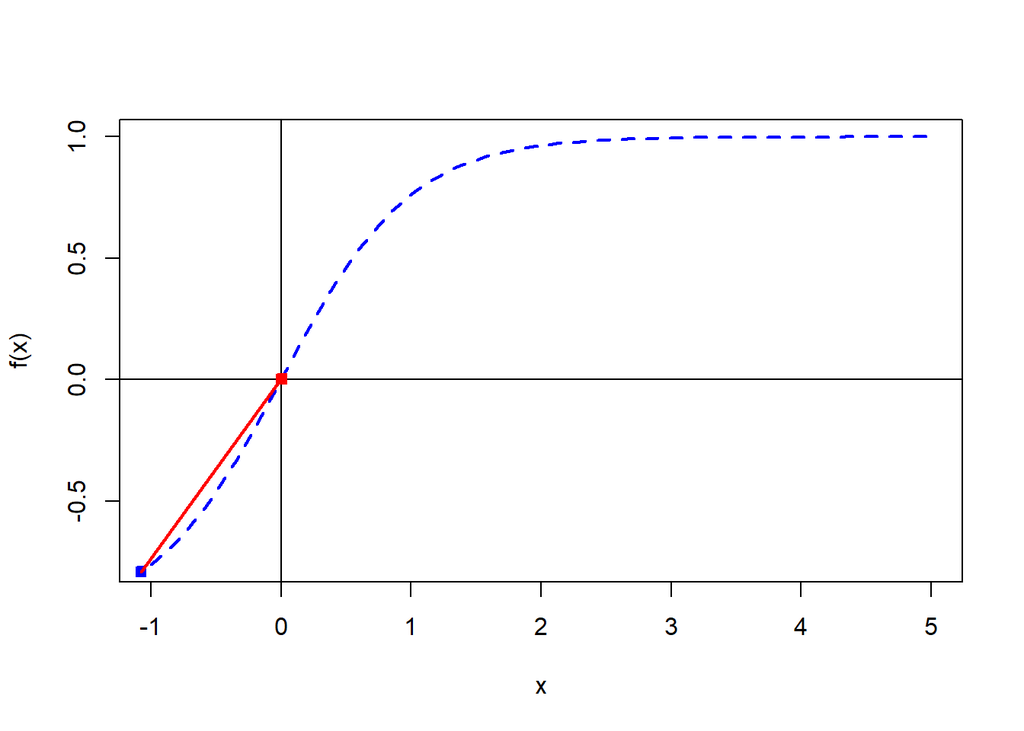

```
## [1] "iteración: 3"
## [1] "valor de x t: 0.00347971457680663"
## [1] "valor de x t+1: -0.00124399481181114"
```

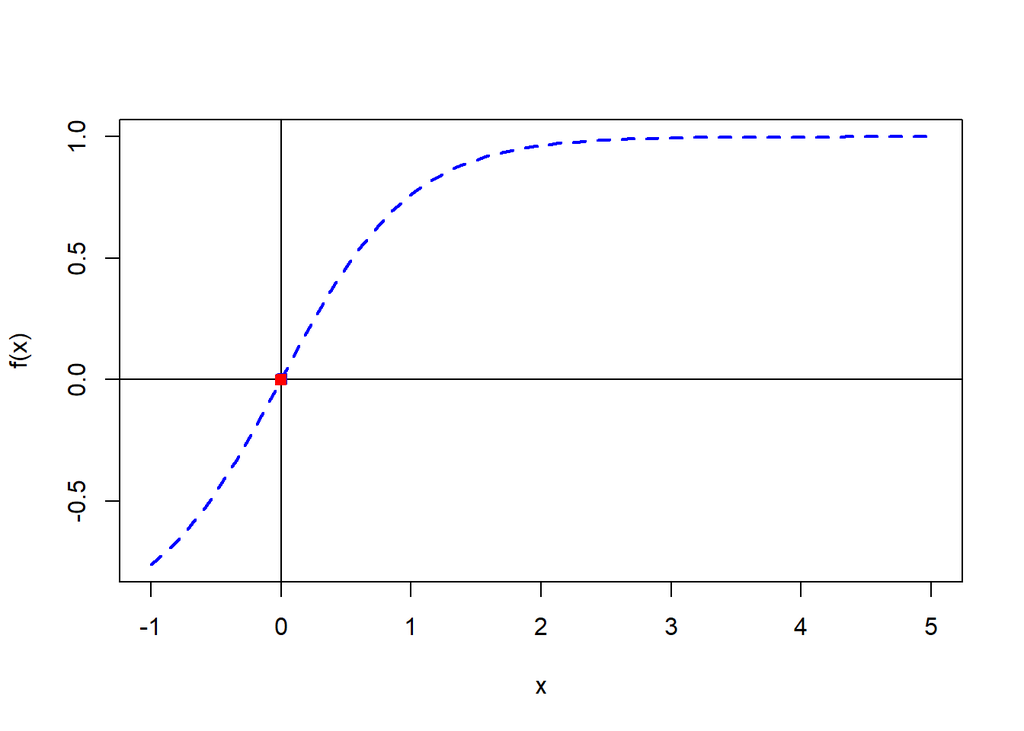

```
## [1] "iteración: 4"
## [1] "valor de x t: -0.00124399481181114"
## [1] "valor de x t+1: 3.22594739419688e-09"
```

```
## [1] "iteración: 5"
## [1] "valor de x t: 3.22594739419688e-09"
## [1] "valor de x t+1: -1.66407154133021e-15"
```

```
## [1] "iteración: 6"
## [1] "valor de x t: -1.66407154133021e-15"
## [1] "valor de x t+1: 0"
```

```
## [1] 0
```

```r
secante(f, 1.08, 1.09)
```

Con el método Secante la solución de la raíz se bajo las condiciones iniciales se encuentra en la iteración número 6.

**c) Resuelva el problema anterior por el método de combinación del bisección y newton entre un intervalo $[-10,15]$. Explica lo que observa**

Se realiza el algoritmo

```r
bisection_Newton <-  function(f, f1, x_L, x_R, eps, s){
  f_L <- f(x_L)
  if (f_L*f(x_R) > 0){
  print('Error! Function does not have opposite');
  print('signs at interval endpoints!');
  }
  x_M <- (x_L + x_R)/2
  f_M <- f(x_M)
  iteration_counter = 1
  interval_Newton = s*(x_R - x_L)  # Limit for swith to Newton
  while ((x_R - x_L) > interval_Newton){
  if (f_L*f_M > 0) {   # i.e., same sign
  x_L = x_M
  f_L = f_M
  }else{
    x_R = x_M;
  }
  x_M <- (x_L + x_R)/2
  f_M <- f(x_M)
  iteration_counter = iteration_counter + 1;
  }
newton(x_M)

  }
```

Se prueba con los valore ya mencionados

```r
f <- function(x) {
  tanh(x)
}
f1 <- function(x) {
  1 - tanh(x)^2
}
eps <- 1e-15
  a <- -10
  b <- 15
  s <- 0.1
  bisection_Newton(f, f1, a, b, eps, s)
```

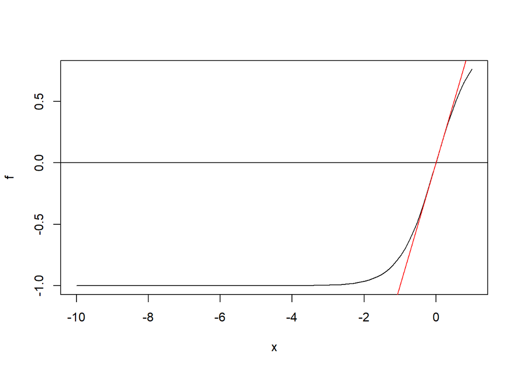

```
## [1] "iteración: 1"
## [1] "valor de x: -0.00255557805678866"
## [1] "iteración: 2"
## [1] "valor de x: 1.11269659631985e-08"
## [1] "iteración: 3"
## [1] "valor de x: -1.65436122510606e-24"
## [1] "iteración: 4"
## [1] "valor de x: 0"
```

Se observa que al utilizar un mpetodo seguro la iteración es segura y se utilizan un número menor de iteraciones.